# Trabajo final: Modelamiento de datos

Cluster de Obesidad

2025-05-24

## 1. Algoritmo Kmeans

K-means es un algoritmo de clustering no supervisado que agrupa los datos en k grupos o clusters, de tal forma que:

- Los datos **dentro de un mismo cluster** son lo **más parecidos posible entre sí**.
- Los datos **entre distintos clusters** son lo **más distintos posible**.

$$\min_{C_1, C_2, \dots, C_k} \sum_{j=1}^{k} \sum_{x_i \in C_j} \| x_i -
\mu_j \|^2$$

| Símbolo | Significado |
| --- | --- |
| $k$ | Número de clusters (debes definirlo antes de aplicar el algoritmo) |
| $x_i$ | Punto de datos número $i$ (observación del conjunto de datos) |
| $C_j$ | Conjunto de puntos asignados al cluster $j$ |
| $\mu_j$ | Centroide del cluster $j$: promedio de todos los puntos en $C_j$ |
| $\\|x_i - \mu_j\\|^2$ | Distancia euclidiana al cuadrado entre el punto $x_i$ y su centroide $\mu_j$ |

## 2. Descripción del dataset

Fuente de datos [Kaggle](https://www.kaggle.com/datasets/aravindpcoder/obesity-or-cvd-risk-classifyregressorcluster).

Los datos consisten en la estimación de los niveles de obesidad en personas de México, Perú y Colombia, con edades comprendidas entre los 14 y los 61 años, y con diversos hábitos alimentarios y condición física. Los datos se recopilaron mediante una plataforma web con una encuesta donde usuarios anónimos respondieron cada pregunta. Posteriormente, se procesó la información, obteniendo 17 atributos y 2111 registros.

Los atributos relacionados con los hábitos alimentarios son:

- consumo frecuente de alimentos de alto valor calórico (FAVC)
- frecuencia de consumo de verduras (FCVC), número de comidas principales (NCP)
- consumo de alimentos entre comidas (CAEC)
- consumo diario de agua (CH20)
- consumo de alcohol (CALC)

Los atributos relacionados con la condición física son:

- monitoreo del consumo de calorías (SCC)
- frecuencia de actividad física (FAF)
- tiempo de uso de dispositivos tecnológicos (TUE)
- transporte utilizado (MTRANS).

## Data managment

```r
# Establecemos la ruta de trabajo
setwd("C:/Users/Rihard/Documents/GitHub/Cluster_obesity")

# Cargar librerías
library(tidyverse)
library(cluster)
library(factoextra)
# Cargar librerías
library(tidyverse)
library(cluster)
library(factoextra)
# Cargar paquetes necesarios
library(tidyverse)
library(caret)
library(FactoMineR)
library(factoextra)
library(recipes)
library(dplyr)

# Leer archivo
data <- read.csv("ObesityDataSet.csv")
```

```r
vars <- c("Gender", "family_history_with_overweight", "FAVC",
          "CAEC", "SMOKE", "SCC", "CALC", "MTRANS")
tables <- lapply(data[vars], table)
tables
```

```
## $Gender
##
## Female   Male
##   1043   1068
##
## $family_history_with_overweight
##
##   no  yes
##  385 1726
##
## $FAVC
##
##   no  yes
##  245 1866
##
## $CAEC
##
##     Always Frequently         no  Sometimes
##         53        242         51       1765
##
## $SMOKE
##
##   no  yes
## 2067   44
##
## $SCC
##
##   no  yes
## 2015   96
##
## $CALC
##
##     Always Frequently         no  Sometimes
##          1         70        639       1401
##
## $MTRANS
##
##            Automobile                  Bike             Motorbike
##                   457                     7                    11
## Public_Transportation               Walking
##                  1580                    56
```

```r
# Eliminamos las variables con más de dos categorías

data <- data %>% select(-MTRANS, -CAEC, -CALC, NObeyesdad)

# Ver primeras filas
head(data)
```

```
##   Gender Age Height Weight family_history_with_overweight FAVC FCVC NCP SMOKE
## 1 Female  21   1.62   64.0                            yes   no    2   3    no
## 2 Female  21   1.52   56.0                            yes   no    3   3   yes
## 3   Male  23   1.80   77.0                            yes   no    2   3    no
## 4   Male  27   1.80   87.0                             no   no    3   3    no
## 5   Male  22   1.78   89.8                             no   no    2   1    no
## 6   Male  29   1.62   53.0                             no  yes    2   3    no
##   CH2O SCC FAF TUE          NObeyesdad
## 1    2  no   0   1       Normal_Weight
## 2    3 yes   3   0       Normal_Weight
## 3    2  no   2   1       Normal_Weight
## 4    2  no   2   0  Overweight_Level_I
## 5    2  no   0   0 Overweight_Level_II
## 6    2  no   0   0       Normal_Weight
```

```r
# Ver estructura
glimpse(data)
```

```
## Rows: 2,111
## Columns: 14
## $ Gender                         <chr> "Female", "Female", "Male", "Male", "Ma…
## $ Age                            <dbl> 21, 21, 23, 27, 22, 29, 23, 22, 24, 22,…
## $ Height                         <dbl> 1.62, 1.52, 1.80, 1.80, 1.78, 1.62, 1.5…
## $ Weight                         <dbl> 64.0, 56.0, 77.0, 87.0, 89.8, 53.0, 55.…
## $ family_history_with_overweight <chr> "yes", "yes", "yes", "no", "no", "no", …
## $ FAVC                           <chr> "no", "no", "no", "no", "no", "yes", "y…
## $ FCVC                           <dbl> 2, 3, 2, 3, 2, 2, 3, 2, 3, 2, 3, 2, 3, …
## $ NCP                            <dbl> 3, 3, 3, 3, 1, 3, 3, 3, 3, 3, 3, 3, 3, …
## $ SMOKE                          <chr> "no", "yes", "no", "no", "no", "no", "n…
## $ CH2O                           <dbl> 2, 3, 2, 2, 2, 2, 2, 2, 2, 2, 3, 2, 3, …
## $ SCC                            <chr> "no", "yes", "no", "no", "no", "no", "n…
## $ FAF                            <dbl> 0, 3, 2, 2, 0, 0, 1, 3, 1, 1, 2, 2, 2, …
## $ TUE                            <dbl> 1, 0, 1, 0, 0, 0, 0, 0, 1, 1, 2, 1, 0, …
## $ NObeyesdad                     <chr> "Normal_Weight", "Normal_Weight", "Norm…
```

```r
# Verificar valores faltantes
colSums(is.na(data))
```

```
##                         Gender                            Age
##                              0                              0
##                         Height                         Weight
##                              0                              0
## family_history_with_overweight                           FAVC
##                              0                              0
##                           FCVC                            NCP
##                              0                              0
##                          SMOKE                           CH2O
##                              0                              0
##                            SCC                            FAF
##                              0                              0
##                            TUE                     NObeyesdad
##                              0                              0
```

```r
# Estadísticas descriptivas
summary(data)
```

```
##     Gender               Age            Height          Weight
##  Length:2111        Min.   :14.00   Min.   :1.450   Min.   : 39.00
##  Class :character   1st Qu.:19.95   1st Qu.:1.630   1st Qu.: 65.47
##  Mode  :character   Median :22.78   Median :1.700   Median : 83.00
##                     Mean   :24.31   Mean   :1.702   Mean   : 86.59
##                     3rd Qu.:26.00   3rd Qu.:1.768   3rd Qu.:107.43
##                     Max.   :61.00   Max.   :1.980   Max.   :173.00
##  family_history_with_overweight     FAVC                FCVC
##  Length:2111                    Length:2111        Min.   :1.000
##  Class :character               Class :character   1st Qu.:2.000
##  Mode  :character               Mode  :character   Median :2.386
##                                                    Mean   :2.419
##                                                    3rd Qu.:3.000
##                                                    Max.   :3.000
##       NCP           SMOKE                CH2O           SCC
##  Min.   :1.000   Length:2111        Min.   :1.000   Length:2111
##  1st Qu.:2.659   Class :character   1st Qu.:1.585   Class :character
##  Median :3.000   Mode  :character   Median :2.000   Mode  :character
##  Mean   :2.686                      Mean   :2.008
##  3rd Qu.:3.000                      3rd Qu.:2.477
##  Max.   :4.000                      Max.   :3.000
##       FAF              TUE          NObeyesdad
##  Min.   :0.0000   Min.   :0.0000   Length:2111
##  1st Qu.:0.1245   1st Qu.:0.0000   Class :character
##  Median :1.0000   Median :0.6253   Mode  :character
##  Mean   :1.0103   Mean   :0.6579
##  3rd Qu.:1.6667   3rd Qu.:1.0000
##  Max.   :3.0000   Max.   :2.0000
```

## Implementación del modelo

```r
rec <- recipe(~., data = data %>% select(-NObeyesdad)) %>%
  step_dummy(all_nominal()) %>%      # convierte a dummies
  step_center(all_numeric()) %>%
  step_scale(all_numeric())

data_clean <- bake(prep(rec), new_data = NULL)

# Escalar datos
data_scaled <- scale(data_clean)
```

## Elegir número óptimo de clusters (elbow method) 3

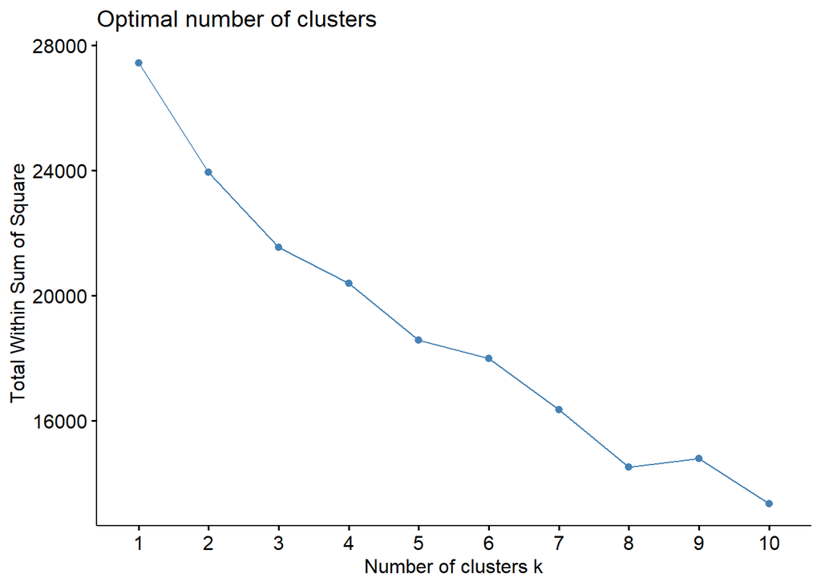

```r
fviz_nbclust(data_scaled, kmeans, method = "wss")
```

## Visualizamos los 3 cluster

Mediante el elbow method

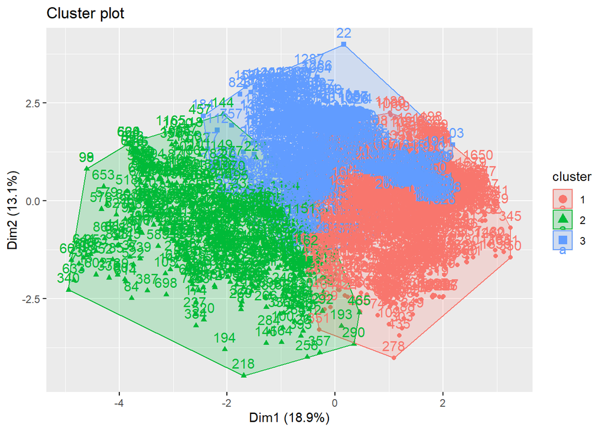

```r
# Ejecutar K-means con 5 clustwers
set.seed(123)
km <- kmeans(data_scaled, centers = 3, nstart = 25)

# Visualizar clusters
fviz_cluster(km, data = data_scaled)
```

## Describimos los cluster generados

```r
# Añadir resultados al dataset original
data_clustered <- data %>% mutate(Cluster = factor(km$cluster))

# Calcular promedios por cluster (solo numéricas)
promedios <- data_clustered %>%
  group_by(Cluster) %>%
  summarise(across(where(is.numeric), mean, na.rm = TRUE))

# Mostrar tabla
print(promedios)
```

```
## # A tibble: 3 × 9
##   Cluster   Age Height Weight  FCVC   NCP  CH2O   FAF   TUE
##   <fct>   <dbl>  <dbl>  <dbl> <dbl> <dbl> <dbl> <dbl> <dbl>
## 1 1        25.1   1.77   94.0  2.26  2.79  2.09 1.19  0.685
## 2 2        20.9   1.63   58.7  2.38  2.50  1.82 1.11  0.658
## 3 3        25.5   1.66   95.1  2.65  2.67  2.02 0.719 0.624
```

## Resultados finales

| Cluster | Perfil general | Edad | Peso (kg) | Altura (m) | FCVC (Verduras) | NCP (Comidas/día) | CH2O (Agua) | FAF (Actividad física) | TUE (Tecnología) | Interpretación |
| --- | --- | --- | --- | --- | --- | --- | --- | --- | --- | --- |
| **1** | Adultos con sobrepeso y hábitos saludables | 25.1 | 94.0 | 1.77 | 2.26 | 2.79 | 2.09 | 1.19 | 0.685 | Sobrepeso alto pero con dieta y actividad aceptables |
| **2** | Jóvenes saludables | 20.9 | 58.7 | 1.63 | 2.38 | 2.50 | 1.82 | 1.11 | 0.658 | Jóvenes con peso normal y buenos hábitos |
| **3** | Adultos con obesidad y bajo ejercicio | 25.5 | 95.1 | 1.66 | 2.65 | 2.67 | 2.02 | 0.72 | 0.624 | Obesidad marcada, dieta aceptable, pero poca actividad física |